# Predicting ms using different machine learning models

```python
# We will import all the required libraries
import pandas as pd
import seaborn as sns
import matplotlib as plt
# from sklearn.linear_model import LogisticRegression
# from sklearn.tree import DecisionTreeClassifier
# from sklearn.neighbors import KNeighborsClassifier
# from sklearn.ensemble import RandomForestClassifier
# from sklearn.svm import SVC
# from sklearn.discriminant_analysis import LinearDiscriminantAnalysis
# from sklearn.naive_bayes import GaussianNB

# from sklearn.metrics import precision_score,recall_score,accuracy_score
```

```python
# Reading the data we have generated already
data = pd.read_excel('SURVEY new (1).xlsx')
data.head() # showing the first five rows using the head() method
```

|  | ID | Gender | Age | Nationality | mi | ms |
| --- | --- | --- | --- | --- | --- | --- |
| 0 | 1.0 | Female | 18.0 | Jordanian | 5.0 | 1.0 |
| 1 | 2.0 | Male | 19.0 | Canadian | 10.0 | 0.3 |
| 2 | 3.0 | Male | 18.0 | Jordanian | 8.0 | 0.8 |
| 3 | 4.0 | Male | 19.0 | Sudanese | 4.0 | 1.8 |
| 4 | 5.0 | Male | 20.0 | Sudanese | 4.0 | 1.4 |

```python
# lets drop the ID column
data = data.drop('ID', axis = 1)
data.head()
```

|  | Gender | Age | Nationality | mi | ms |
| --- | --- | --- | --- | --- | --- |
| 0 | Female | 18.0 | Jordanian | 5.0 | 1.0 |
| 1 | Male | 19.0 | Canadian | 10.0 | 0.3 |
| 2 | Male | 18.0 | Jordanian | 8.0 | 0.8 |
| 3 | Male | 19.0 | Sudanese | 4.0 | 1.8 |
| 4 | Male | 20.0 | Sudanese | 4.0 | 1.4 |

```python
# Lets check missing values
data.isnull().sum()
```

```
Gender         42
Age            42
Nationality    42
mi             42
ms             42
dtype: int64
```

As we can see that we have some missing values

- the treatment of these values is to remove them
- these values are because of wrong entries

```python
# removing the missing values
data.dropna(inplace = True)
```

```python
# Checking the missing values again
data.isnull().sum()
```

```
Gender         0
Age            0
Nationality    0
mi             0
ms             0
dtype: int64
```

We have left with zero missing values

```
          Age        mi        ms
Age  1.000000  0.194451  0.099420
mi   0.194451  1.000000  0.410836
ms   0.099420  0.410836  1.000000
```

```
<module 'matplotlib' from 'C:\\ProgramData\\Anaconda3\\lib\\site-packages\\matplotlib\\__init__.py'>
```

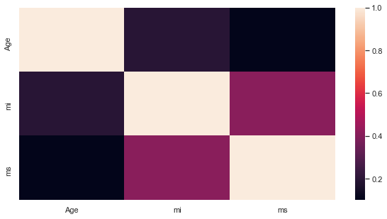

```python
# plotting the correlation graph
corr = data.corr()
print(corr)
sns.set(rc = {'figure.figsize':(10,5)})
sns.heatmap(corr,xticklabels=corr.columns,yticklabels=corr.columns)
plt
```

```python
# decsription of the dataset
data.describe()
```

|  | Age | mi | ms |
| --- | --- | --- | --- |
| count | 64.000000 | 64.000000 | 64.000000 |
| mean | 22.750000 | 7.275000 | 1.876562 |
| std | 4.472136 | 2.955168 | 1.311093 |
| min | 18.000000 | 2.000000 | 0.300000 |
| 25% | 19.750000 | 5.000000 | 0.975000 |
| 50% | 21.000000 | 7.000000 | 1.500000 |
| 75% | 26.000000 | 9.000000 | 2.500000 |
| max | 34.000000 | 15.000000 | 5.500000 |

```python
# lets check the Nationality column
data.Nationality.unique()
```

```
array(['Jordanian', 'Canadian', 'Sudanese', 'Syrian', 'Libya',
       'Egyptian ', 'Moroccan ', 'Jordanian ', 'Palestinian', 'Iraq',
       'Sudanese ', 'Yemen', 'Pakistan', 'syrian'], dtype=object)
```

```python
# # lets check the gender feature
data.Gender.unique()
```

```
array(['Female', 'Male', 'female'], dtype=object)
```

There is a problem with the Gender column

- the female word is entered twice
- Female
- female We will convert these values into 0s and 1s
- because machine learning models don't understand categorical values
- we will convert them into numerical values
- 0 for Male
- 1 for female

```python
# Replacing Female and female as 1
data["Gender"] = data["Gender"].replace(['Female', 'female'], 1)
```

```python
# Now replace the Male with 0
data["Gender"] = data["Gender"].replace(['Male'], 0)
```

```python
data.Gender.unique()
```

```
array([1, 0], dtype=int64)
```

As you can see that the Gender column in now converted into 0 and 1

- 0 means Male
- 1 means Female

Now lets convert the Nationality column into numerical values

- because machine learning models only understand numerical values
- we will use the Python's Map technique to convert the countries names into numbers

```python
# we will convert the nationalities into specific numbers
# we will give each country a special number
data['Nationality'] = data['Nationality'].map(
    {
        'Jordanian':0,
        'Canadian':1,
        'Sudanese':2,
        'Syrian':3,
        'Libya':4,
        'Egyptian ':5,
        'Moroccan ':6,
        'Jordanian ':7,
        'Palestinian':8,
        'Iraq':9,
        'Sudanese ':2,
        'Yemen':11,
        'Pakistan':12,
        'syrian':3,

    }
)
```

```python
# the nationality is now converted into numerical values
data.Nationality.unique()
```

```
array([ 0,  1,  2,  3,  4,  5,  6,  7,  8,  9, 11, 12], dtype=int64)
```

# Splitting the data

Now we will split the data into test and train set

- the train set will be used to train the models
- the test set will be used to test the models the goal of this project is predict 'ms' based on all the other features, so:
- ms is the dependent feature
- all the other columns are independent

```python
# we will store the independent features in X variable
X = data.drop('ms', axis = 1)
```

```python
# store the dependent variable ms in y
Y = data['ms']
```

```python
# now we will import the test and train fucntion to split the data into test and train set
# Splitting the data into train and test sets
from sklearn.model_selection import train_test_split
X_train, X_test, y_train, y_test = train_test_split(X, Y, test_size = 0.1, random_state = 1)
```

# Model building

```python
# importing the machine learning models from sklearn
from sklearn.tree import DecisionTreeRegressor
from sklearn.linear_model import LinearRegression
from sklearn.ensemble import RandomForestRegressor
from sklearn.metrics import mean_squared_error, mean_absolute_error
from sklearn.ensemble import AdaBoostRegressor,GradientBoostingRegressor,RandomForestRegressor
from sklearn.neighbors import KNeighborsRegressor
from xgboost import XGBRegressor
```

# Linear Regression

```python
# Training the Linear Regression model
lr_clf = LinearRegression()
lr_clf.fit(X_train,y_train)
lr_predict = lr_clf.predict(X_test)
```

```python
lr_predict # prediction using Linear regression
```

```
array([2.30681266, 1.78127422, 2.89554479, 1.66348657, 2.68560158,
       1.93659654, 1.75662217])
```

```python
print('MSE = ',mean_squared_error(y_test,lr_predict))
print("r2 score : ",r2_score(y_test,lr_predict))
print("MSE : ",mean_squared_error(y_test,lr_predict))
print("MAE : ",mean_absolute_error(y_test,lr_predict))
```

```
MSE =  1.4534648267506858
r2 score :  -2.1429733676427003
MSE :  1.4534648267506858
MAE :  1.1160991690138262
```

### XGBoost

```python
#this function used to evalute the models with features and terget.
def models_score(models, x_train, x_test, y_train, y_test):
    scores = {}
    for name, model in models.items():
        model.fit(x_train, y_train)
        y_pred=model.predict(x_test)
        scores[name] =r2_score(y_test,y_pred)
        #printing the model name and accuracy !!!!!
        print("Model name: ",model)
        print("R2 score :--->>",r2_score(y_test,y_pred))
        print("MSE",mean_squared_error(y_test,y_pred))
        print("MAE",mean_absolute_error(y_test,y_pred))
        print("\n<<<<------------------------------------------------------------->>>>\n")


    model_scores = pd.DataFrame(scores, index=['score']).transpose()
    model_scores = model_scores.sort_values('score',ascending=False)
    return model_scores
```

```python
#initialize the models
models = {"GradiantBoost":GradientBoostingRegressor(random_state=22, n_estimators = 142),
         "RandomForest":RandomForestRegressor(random_state=150),
         "XGBboost":XGBRegressor(random_state=22, n_estimators = 142)}
```

```python
#Calling the function
model_scores = models_score(models, X_train, X_test, y_train, y_test)
```

```
Model name:  GradientBoostingRegressor(n_estimators=142, random_state=22)
R2 score :--->> -3.1616638570192865
MSE 1.924557204082797
MAE 1.2819113427282733

<<<<------------------------------------------------------------->>>>

Model name:  RandomForestRegressor(random_state=150)
R2 score :--->> -1.3626850397175665
MSE 1.092621285714287
MAE 0.9270000000000005

<<<<------------------------------------------------------------->>>>

Model name:  XGBRegressor(base_score=0.5, booster='gbtree', colsample_bylevel=1,
             colsample_bynode=1, colsample_bytree=1, enable_categorical=False,
             gamma=0, gpu_id=-1, importance_type=None,
             interaction_constraints='', learning_rate=0.300000012,
             max_delta_step=0, max_depth=6, min_child_weight=1, missing=nan,
             monotone_constraints='()', n_estimators=142, n_jobs=8,
             num_parallel_tree=1, predictor='auto', random_state=22,
             reg_alpha=0, reg_lambda=1, scale_pos_weight=1, subsample=1,
             tree_method='exact', validate_parameters=1, verbosity=None)
R2 score :--->> -1.4596431540692776
MSE 1.1374594667593845
MAE 0.9604703256062098

<<<<------------------------------------------------------------->>>>
```

```python
#printing the model score
model_scores
```

|  | score |
| --- | --- |
| RandomForest | -1.362685 |
| XGBboost | -1.459643 |
| GradiantBoost | -3.161664 |

### ADA Boost

```python
model = AdaBoostRegressor(n_estimators=500 ,learning_rate=0.001)
model.fit(X_train,y_train)
```

```
AdaBoostRegressor(learning_rate=0.001, n_estimators=500)
```

```python
model.score(X_test,y_test)
```

```
-1.067614052639101
```

```python
ada_pred = model.predict(X_test)
ada_pred
```

```
array([2.03181818, 1.46060606, 2.5875    , 1.61428571, 2.00833333,
       2.15238095, 2.        ])
```

```python
print("r2 score : ",r2_score(y_test,ada_pred))
print("MSE : ",mean_squared_error(y_test,ada_pred))
print("MAE : ",mean_absolute_error(y_test,ada_pred))
```

```
r2 score :  -1.067614052639101
MSE :  0.9561660088326944
MAE :  0.8792748917748917
```

We have trained many regression models as shown above